# Correlations of stream gage info with Pekel and DSWE 2.0 data in California’s Central Valley

#### Workflow

For all 50 HUCs in the Central Valley:

- Retrieve compiled Pekel data (JRC Global Surface Monthly Water History)
- Retrieve compiled DSWE v2.0 data (monthly composites)
- Clean data
  - Restrict values to those from images with < 10% NoData pixels
- Retrieve monthly stage height and discharge data from all CV stream gages (NWIS)
- Calculate Pearson correlation between discharge and imagery area of water
  - In same HUCs
  - In all HUCs

#### Geographical Area

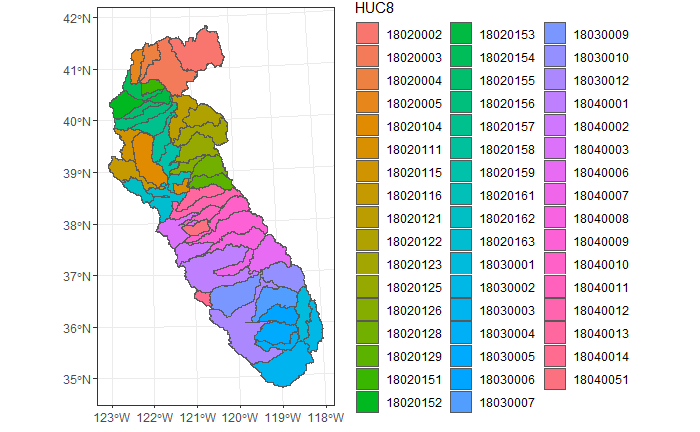

#### Difference in proportion of contaminated pixels (DSWE, Pekel)

Only values from images with less than **10**% NoData pixels are used in correlations.

Pekel and DSWE data show different proportions of NoData pixels (clouds, cloud shadows, or snow). In general, DSWE data have lower proportions of contaminated pixels.

##### Boxplot

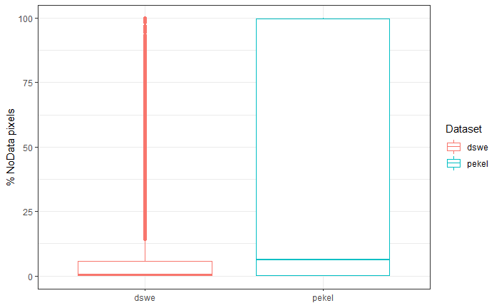

##### Scatterplot of average percent of NoData pixels (across all HUCs) by date

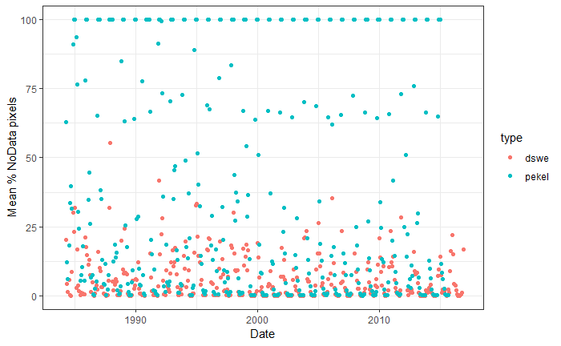

[output not shown]

#### Gage:imagery correlations in each HUC

The *highest* Pearson correlations between monthly imagery data and monthly streamgage discharge/height data for each HUC are below. Bolded values are > 0.5.

| HUC | Gage | Data type | Gage type | r | n |
| --- | --- | --- | --- | --- | --- |
| 18020002 | 11351945 | dswe | discharge | 0.834 | 73 |
| 18020003 | 11362945 | pekel | discharge | 0.842 | 133 |
| 18020004 | 11367500 | pekel | discharge | 0.707 | 163 |
| 18020005 | 11342000 | pekel | discharge | 0.289 | 162 |
| 18020104 | 11389000 | dswe | discharge | 0.358 | 98 |
| 18020111 | 11447293 | pekel | discharge | 0.472 | 99 |
| 18020116 | 11450000 | pekel | gage ht | 0.657 | 228 |
| 18020121 | 11404900 | pekel | discharge | 0.569 | 166 |
| 18020122 | 11401165 | pekel | discharge | 0.760 | 146 |
| 18020123 | 11396395 | pekel | discharge | 0.736 | 104 |
| 18020125 | 11414170 | pekel | discharge | 0.716 | 165 |
| 18020126 | 11423800 | pekel | discharge | 0.451 | 198 |
| 18020128 | 11433085 | pekel | discharge | 0.677 | 20 |
| 18020129 | 11436510 | pekel | discharge | 0.752 | 27 |
| 18020151 | 11372330 | pekel | discharge | 0.628 | 155 |
| 18020152 | 11374300 | pekel | discharge | 0.780 | 63 |
| 18020153 | 11376150 | pekel | discharge | 0.401 | 148 |
| 18020154 | 11370700 | dswe | discharge | 0.389 | 173 |
| 18020155 | 11377100 | dswe | discharge | 0.575 | 320 |
| 18020156 | 11381500 | pekel | discharge | 0.716 | 200 |
| 18020157 | 11383500 | pekel | discharge | 0.770 | 225 |
| 18020158 | 11390000 | pekel | discharge | 0.437 | 214 |
| 18020159 | 11406930 | pekel | discharge | 0.260 | 228 |
| 18020161 | 11425415 | dswe | discharge | 0.107 | 260 |
| 18020162 | 11453500 | pekel | discharge | 0.439 | 145 |
| 18020163 | 11452901 | pekel | discharge | 0.726 | 23 |
| 18030001 | 11185500 | pekel | discharge | 0.558 | 143 |
| 18030002 | 11189500 | pekel | discharge | 0.389 | 193 |
| 18030003 | 11192950 | pekel | discharge | 0.674 | 228 |
| 18030005 | 11200800 | dswe | discharge | 0.502 | 296 |
| 18030006 | 11201450 | pekel | discharge | 0.734 | 180 |
| 18030007 | 11208600 | pekel | discharge | 0.787 | 155 |
| 18030009 | 11253310 | dswe | discharge | 0.449 | 293 |
| 18030010 | 11214600 | pekel | discharge | 0.541 | 135 |
| 18030012 | 11224500 | pekel | discharge | 0.285 | 260 |
| 18040001 | 11262900 | pekel | discharge | 0.674 | 254 |
| 18040002 | 11274550 | dswe | discharge | 0.891 | 198 |
| 18040003 | 11337600 | dswe | discharge | 0.266 | 127 |
| 18040006 | 11243405 | pekel | discharge | 0.857 | 23 |
| 18040008 | 11270900 | pekel | discharge | 0.637 | 163 |
| 18040009 | 11289651 | pekel | discharge | 0.642 | 136 |
| 18040010 | 11293462 | pekel | discharge | 0.712 | 52 |
| 18040012 | 11323500 | pekel | discharge | 0.514 | 161 |
| 18040013 | 11335655 | pekel | discharge | 0.848 | 60 |
| 18040014 | 11255575 | pekel | discharge | 0.259 | 84 |

#### Gage:imagery correlation across all HUCs

Opening up the analysis to all gages, no matter what HUC they’re in, reveals that the majority of imagery datasets have a stronger correlation with a gage that is outside that particular HUC (in red).

| HUC - imagery | Gage w best correlation | HUC - gage | Data type | r | Same HUC? | n |
| --- | --- | --- | --- | --- | --- | --- |
| 18020002 | 11293500 | 18040010 | pekel | 0.873 | N | 2 |
| 18020003 | 11452900 | 18020163 | pekel | 0.896 | N | 4 |
| 18020004 | 11453000 | 18020163 | pekel | 0.912 | N | 5 |
| 18020005 | 11453000 | 18020163 | pekel | 0.913 | N | 5 |
| 18020104 | 11293500 | 18040010 | dswe | 0.713 | N | 2 |
| 18020111 | 11453000 | 18020163 | pekel | 0.648 | N | 5 |
| 18020115 | 11450000 | 18020116 | pekel | 0.858 | N | 1 |
| 18020116 | 11364250 | 18020003 | pekel | 0.721 | N | 2 |
| 18020121 | 11291500 | 18040010 | dswe | 1.000 | N | 3 |
| 18020122 | 11206820 | 18030007 | pekel | 0.871 | N | 5 |
| 18020123 | 11453000 | 18020163 | pekel | 0.856 | N | 5 |
| 18020125 | 11243405 | 18040006 | pekel | 0.866 | N | 6 |
| 18020126 | 11206820 | 18030007 | pekel | 0.742 | N | 5 |
| 18020128 | 11243405 | 18040006 | pekel | 0.869 | N | 6 |
| 18020129 | 11208800 | 18030007 | pekel | 0.768 | N | 1 |
| 18020151 | 11364250 | 18020003 | pekel | 0.784 | N | 2 |
| 18020152 | 11361000 | 18020003 | pekel | 0.784 | N | 1 |
| 18020153 | 11206820 | 18030007 | pekel | 0.744 | N | 5 |
| 18020154 | 11253058 | 18040001 | pekel | 0.494 | N | 2 |
| 18020155 | 11253058 | 18040001 | pekel | 0.740 | N | 2 |
| 18020156 | 11453000 | 18020163 | pekel | 0.949 | N | 5 |
| 18020157 | 11335655 | 18040013 | pekel | 0.863 | N | 2 |
| 18020158 | 11206820 | 18030007 | pekel | 0.638 | N | 5 |
| 18020159 | 11442700 | 18020129 | dswe | 0.586 | N | 1 |
| 18020161 | 11206820 | 18030007 | pekel | 0.749 | N | 5 |
| 18020162 | 11355500 | 18020003 | pekel | 0.849 | N | 1 |
| 18020163 | 11451715 | 18020116 | pekel | 0.813 | N | 1 |
| 18030001 | 11243405 | 18040006 | pekel | 0.949 | N | 6 |
| 18030002 | 11413517 | 18020125 | dswe | 0.831 | N | 3 |
| 18030003 | 11325500 | 18040012 | pekel | 0.794 | N | 1 |
| 18030004 | 11426000 | 18020161 | dswe | 0.881 | N | 1 |
| 18030005 | 11452900 | 18020163 | pekel | 0.819 | N | 4 |
| 18030006 | 11291500 | 18040010 | dswe | 0.855 | N | 3 |
| 18030007 | 11224000 | 18040006 | pekel | 0.879 | N | 1 |
| 18030009 | 11452800 | 18020163 | pekel | 0.711 | N | 2 |
| 18030010 | 11243405 | 18040006 | pekel | 0.937 | N | 6 |
| 18030012 | 11452800 | 18020163 | pekel | 0.841 | N | 2 |
| 18040001 | 11262900 | 18040001 | pekel | 0.727 | Y | 1 |
| 18040002 | 11274550 | 18040002 | pekel | 0.901 | Y | 1 |
| 18040003 | 11374300 | 18020152 | pekel | 0.472 | N | 1 |
| 18040006 | 11291500 | 18040010 | dswe | 1.000 | N | 3 |
| 18040007 | 11413517 | 18020125 | dswe | 0.781 | N | 3 |
| 18040008 | 11243405 | 18040006 | pekel | 0.932 | N | 6 |
| 18040009 | 11243405 | 18040006 | pekel | 0.921 | N | 6 |
| 18040010 | 11452900 | 18020163 | pekel | 0.973 | N | 4 |
| 18040011 | 11413517 | 18020125 | pekel | 0.692 | N | 3 |
| 18040012 | 11452900 | 18020163 | pekel | 0.983 | N | 4 |
| 18040013 | 11335655 | 18040013 | pekel | 0.880 | Y | 2 |
| 18040014 | 11245300 | 18040006 | pekel | 0.776 | N | 1 |
| 18040051 | 11202750 | 18030006 | dswe | 0.721 | N | 1 |

The ‘super gage’ here is site 11243405 in HUC 18040006

#### Correlations between DSWE water categories and gage discharge

Gage discharge and “highest confidence” water extent generally have the highest correlations.

| HUC | Site | Data type | Gage type | r (w1) | r (w1+w2) | r (w1+w2+w3) | r (w1+w2+w3+w4) | n |
| --- | --- | --- | --- | --- | --- | --- | --- | --- |
| 18020002 | 11351945 | dswe | discharge | 0.807 | 0.806 | 0.668 | 0.277 | 65 |
| 18020003 | 11362945 | dswe | discharge | 0.829 | 0.670 | -0.125 | -0.149 | 135 |
| 18020004 | 11367500 | dswe | discharge | 0.616 | 0.093 | -0.170 | -0.179 | 199 |
| 18020005 | 11342000 | dswe | discharge | 0.339 | 0.351 | 0.346 | -0.028 | 261 |
| 18020104 | 11389000 | dswe | discharge | 0.317 | 0.353 | 0.397 | 0.516 | 91 |
| 18020111 | 11447293 | dswe | discharge | 0.481 | 0.270 | 0.388 | 0.438 | 116 |
| 18020116 | 11450000 | dswe | gage ht | 0.272 | 0.279 | 0.281 | 0.180 | 266 |
| 18020121 | 11404900 | dswe | discharge | 0.246 | 0.232 | 0.129 | 0.033 | 179 |
| 18020122 | 11402000 | dswe | discharge | 0.584 | 0.352 | -0.011 | 0.032 | 242 |
| 18020123 | 11406820 | dswe | discharge | 0.523 | 0.419 | 0.004 | -0.175 | 231 |
| 18020125 | 11420770 | dswe | discharge | 0.492 | 0.160 | -0.200 | -0.306 | 174 |
| 18020126 | 11422500 | dswe | discharge | 0.372 | 0.382 | 0.313 | 0.200 | 280 |
| 18020128 | 11428600 | dswe | discharge | 0.478 | 0.344 | -0.044 | -0.132 | 236 |
| 18020129 | 11441800 | dswe | discharge | 0.555 | 0.295 | -0.005 | -0.136 | 204 |
| 18020151 | 11374000 | dswe | discharge | 0.437 | 0.375 | 0.362 | 0.277 | 310 |
| 18020152 | 11376000 | dswe | discharge | 0.638 | 0.479 | 0.374 | 0.440 | 294 |
| 18020153 | 11376150 | dswe | discharge | 0.148 | -0.010 | -0.169 | -0.396 | 201 |
| 18020154 | 11370700 | dswe | discharge | 0.352 | -0.004 | -0.460 | -0.521 | 163 |
| 18020155 | 11377100 | dswe | discharge | 0.576 | 0.401 | 0.278 | 0.310 | 303 |
| 18020156 | 11381500 | dswe | discharge | 0.592 | 0.317 | 0.300 | 0.296 | 311 |
| 18020157 | 11383500 | dswe | discharge | 0.636 | 0.085 | 0.109 | 0.244 | 301 |
| 18020158 | 11389720 | dswe | discharge | 0.349 | 0.372 | 0.378 | 0.312 | 197 |
| 18020159 | 11406999 | dswe | discharge | 0.219 | 0.209 | 0.227 | 0.230 | 242 |
| 18020161 | 11425415 | dswe | discharge | 0.099 | 0.122 | 0.111 | 0.045 | 253 |
| 18020162 | 11454000 | dswe | discharge | 0.244 | 0.246 | 0.177 | 0.007 | 300 |
| 18020163 | 11447650 | dswe | discharge | 0.672 | 0.688 | 0.644 | 0.492 | 268 |
| 18030001 | 11186001 | dswe | discharge | 0.185 | 0.129 | -0.225 | -0.270 | 246 |
| 18030002 | 11189500 | dswe | discharge | 0.378 | 0.390 | 0.280 | -0.038 | 221 |
| 18030003 | 11192950 | dswe | discharge | 0.491 | 0.481 | 0.363 | 0.005 | 268 |
| 18030005 | 11200800 | dswe | discharge | 0.515 | 0.520 | 0.485 | 0.172 | 286 |
| 18030006 | 11201450 | dswe | discharge | 0.681 | 0.048 | 0.037 | -0.151 | 194 |
| 18030007 | 11208600 | dswe | discharge | 0.716 | 0.545 | 0.182 | -0.197 | 193 |
| 18030009 | 11253310 | dswe | discharge | 0.451 | 0.239 | 0.259 | 0.151 | 267 |
| 18030010 | 11214600 | dswe | discharge | 0.321 | 0.045 | -0.234 | -0.181 | 208 |
| 18030012 | 11224500 | dswe | discharge | 0.252 | 0.267 | 0.281 | 0.249 | 278 |
| 18040001 | 11262900 | dswe | discharge | 0.610 | 0.597 | 0.624 | 0.615 | 272 |
| 18040002 | 11274550 | dswe | discharge | 0.898 | 0.345 | 0.377 | 0.343 | 189 |
| 18040003 | 11337600 | dswe | discharge | 0.213 | 0.115 | 0.166 | 0.241 | 123 |
| 18040006 | 11238400 | dswe | discharge | 0.539 | 0.298 | -0.085 | -0.032 | 187 |
| 18040008 | 11270900 | dswe | discharge | 0.397 | 0.128 | -0.186 | -0.159 | 263 |
| 18040009 | 11289651 | dswe | discharge | 0.291 | 0.149 | -0.223 | -0.190 | 224 |
| 18040010 | 11298650 | dswe | discharge | 0.459 | 0.405 | 0.227 | 0.174 | 80 |
| 18040012 | 11325500 | dswe | discharge | 0.543 | 0.423 | 0.359 | 0.233 | 259 |
| 18040013 | 11335655 | dswe | discharge | 0.758 | 0.348 | 0.452 | 0.407 | 72 |
| 18040014 | 11255575 | dswe | discharge | 0.112 | 0.128 | 0.224 | 0.738 | 97 |

#### Individual correlations

Highest correlation: HUC 18040002, gage 11274550 (r = 0.89)

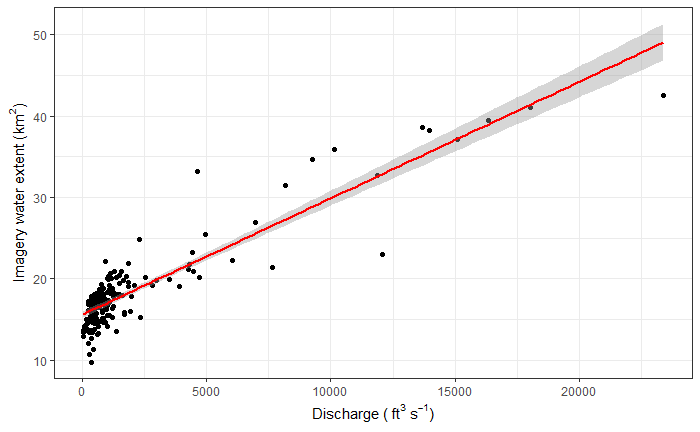

#### Pekel vs. DSWE correlations

| HUC | r | n (Pekel) | n (DSWE) |
| --- | --- | --- | --- |
| 18020002 | 0.921 | 167 | 201 |
| 18020003 | 0.845 | 165 | 189 |
| 18020004 | 0.899 | 141 | 200 |
| 18020005 | 0.882 | 145 | 262 |
| 18020104 | 0.717 | 229 | 276 |
| 18020111 | 0.547 | 212 | 277 |
| 18020115 | 0.843 | 208 | 320 |
| 18020116 | 0.776 | 221 | 274 |
| 18020121 | 0.853 | 154 | 180 |
| 18020122 | 0.716 | 174 | 243 |
| 18020123 | 0.830 | 161 | 232 |
| 18020125 | 0.674 | 152 | 239 |
| 18020126 | 0.786 | 226 | 281 |
| 18020128 | 0.834 | 151 | 246 |
| 18020129 | 0.775 | 146 | 234 |
| 18020151 | 0.554 | 209 | 311 |
| 18020152 | 0.759 | 209 | 295 |
| 18020153 | 0.405 | 152 | 240 |
| 18020154 | 0.421 | 217 | 282 |
| 18020155 | 0.627 | 235 | 304 |
| 18020156 | 0.550 | 173 | 312 |
| 18020157 | 0.588 | 194 | 302 |
| 18020158 | 0.755 | 198 | 254 |
| 18020159 | 0.698 | 224 | 258 |
| 18020161 | 0.716 | 219 | 273 |
| 18020162 | 0.799 | 236 | 301 |
| 18020163 | 0.771 | 226 | 268 |
| 18030001 | 0.775 | 130 | 247 |
| 18030002 | 0.935 | 190 | 236 |
| 18030003 | 0.647 | 230 | 307 |
| 18030004 | 0.693 | 247 | 299 |
| 18030005 | 0.804 | 250 | 287 |
| 18030006 | 0.788 | 230 | 287 |
| 18030007 | 0.727 | 174 | 276 |
| 18030009 | 0.652 | 231 | 268 |
| 18030010 | 0.645 | 108 | 208 |
| 18030012 | 0.712 | 240 | 278 |
| 18040001 | 0.748 | 246 | 286 |
| 18040002 | 0.643 | 259 | 286 |
| 18040003 | 0.572 | 224 | 273 |
| 18040006 | 0.623 | 101 | 195 |
| 18040007 | 0.842 | 251 | 285 |
| 18040008 | 0.846 | 133 | 264 |
| 18040009 | 0.807 | 121 | 226 |
| 18040010 | 0.901 | 138 | 247 |
| 18040011 | 0.865 | 240 | 294 |
| 18040012 | 0.720 | 146 | 276 |
| 18040013 | 0.644 | 214 | 321 |
| 18040014 | 0.699 | 260 | 283 |
| 18040051 | 0.696 | 240 | 281 |

Is there any spatial pattern to the correlations?

#### Pekel vs. DSWE correlations

Where do the two imagery datasets agree/disagree?

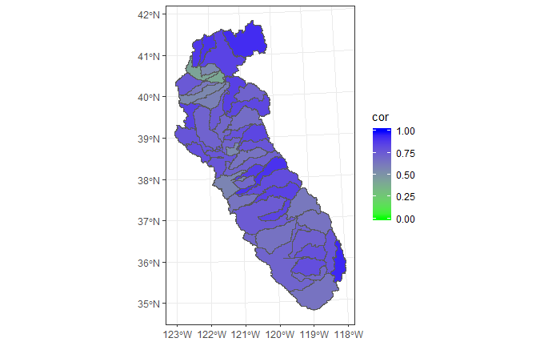

#### DSWE vs. gage correlations

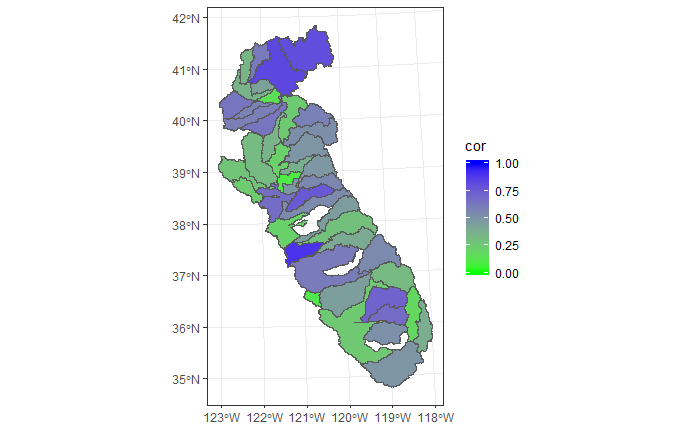

#### Pekel vs. gage correlations

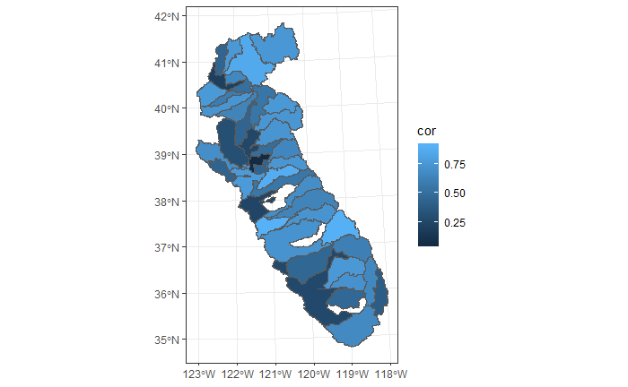

Where do the DSWE/Pekel correlations (imagery:gage) differ?

#### Absolute differences between DSWE/gage and Pekel/gage r values

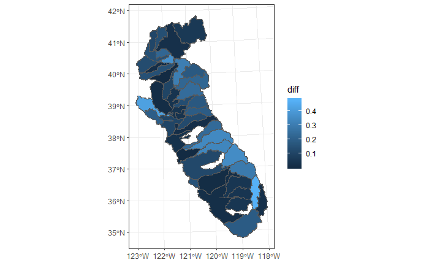

[output not shown]